# ChallengeB Final

Simonet Molly and Palhol Sarah

6/12/2017

https://github.com/MollyTSE/ChallengeB-Palhol-Simonet

# Task 1

## Question 1

We choose the random forest machine learning technique. It is capable of doing regressions and classifications. It classifies explanatory variables depending on the explained variable, thus we can see the links between those 2 types of variables. It is composed of “a forest” of decision trees. Those trees have differents subsamples of the data. The subsamples are randomly drawn from the initial data. The more tree in the forest the more robust it is.To classifie a new object based on attributes, each tree gives a classifiction, and we say the tree votes for that class. The forest chooses the tree with the most votes of all the other trees in the forest.

## Question 2

First we clean the database by using the code of the challenge A

```r
set.seed(1)
train <- read.csv("~/Documents/M1/rprog/train.csv")
test <- read.csv("~/Documents/M1/rprog/test.csv")

require("tidyr")
require(randomForest)
library(randomForest)
library(dplyr)
library(ggplot2)
train$Id = NULL
remove.vars <- train %>% summarise_all(.funs = funs(sum(is.na(.)))) %>% gather(key = "feature", value = "missing.observations") %>% filter(missing.observations > 100) %>% select(feature) %>% unlist

train <- train %>% select(- one_of(remove.vars))

train %>% summarise_all(.funs = funs(sum(is.na(.)))) %>% gather(key = "feature", value = "missing.observations") %>% filter(missing.observations > 0)

train <- train %>% filter(is.na(GarageType) == FALSE, is.na(MasVnrType) == FALSE, is.na(BsmtFinType2) == FALSE, is.na(BsmtExposure) == FALSE, is.na(Electrical) == FALSE)


# make sure it's all clean : Yes
train %>% summarise_all(.funs = funs(sum(is.na(.)))) %>% gather(key = "feature", value = "missing.observations") %>% filter(missing.observations > 0)

cat_var <- train %>% summarise_all(.funs = funs(is.character(.))) %>% gather(key = "feature", value = "is.chr") %>% filter(is.chr == TRUE) %>% select(feature) %>% unlist
# cat_var is the vector of variable names that are stored as character

train %>% mutate_at(.cols = cat_var, .funs = as.factor)

cat_var <- test %>% summarise_all(.funs = funs(is.character(.))) %>% gather(key = "feature", value = "is.chr") %>% filter(is.chr == TRUE) %>% select(feature) %>% unlist
# cat_var is the vector of variable names that are stored as character

test %>% mutate_at(.cols = cat_var, .funs = as.factor)
```

```r
train.rf <- randomForest(SalePrice ~ MSZoning + LotArea + Neighborhood + YearBuilt + OverallQual, data=train, ntree=10, set.seed(1))
summary(train.rf)
```

We use random forest to train the data on relevant variables. We set the seed at 1 and the number of trees at 10.

## Question 3

```r
prediction <- predict(train.rf, test, norm.votes = TRUE)

prediction <- predict(train.rf,test,norm.votes=TRUE)

predictionframe <- data.frame(SalePrice_predict= prediction)

summary(predictionframe)

linearmodel <- lm(SalePrice ~ MSZoning + LotArea + Neighborhood +
                    YearBuilt + OverallQual, data=train)
summary(linearmodel)
```

We predict the test data with the command “predict”. We then predict a linear model using the same variables as with random forest.

# Task 2

We create the data from the challenge A

```r
library(lattice)
set.seed(1)
library(tidyverse)
library(np)
library(caret)
xd <- rnorm(n = 150)
ed <- rnorm(n=150)
yd <- xd^3 + ed
draws <- data.frame(yd,xd)

training.index <- createDataPartition(y = yd, times = 1, p = 0.8)
draws <- draws %>% mutate(which.data = ifelse(1:n() %in% training.index$Resample1, "training", "test"))

training <- draws %>% filter(which.data == "training")
test <- draws %>% filter(which.data == "test")
```

## Question 1

```r
ll.fit.lowflex <- npreg(yd~xd^3 ,method="ll",bws =  0.5,data=training )
summary(ll.fit.lowflex)
```

## Question 2

```r
ll.fit.highflex <- npreg(yd~xd^3 ,method="ll",bws =  0.01,data=training)
```

## Question 3

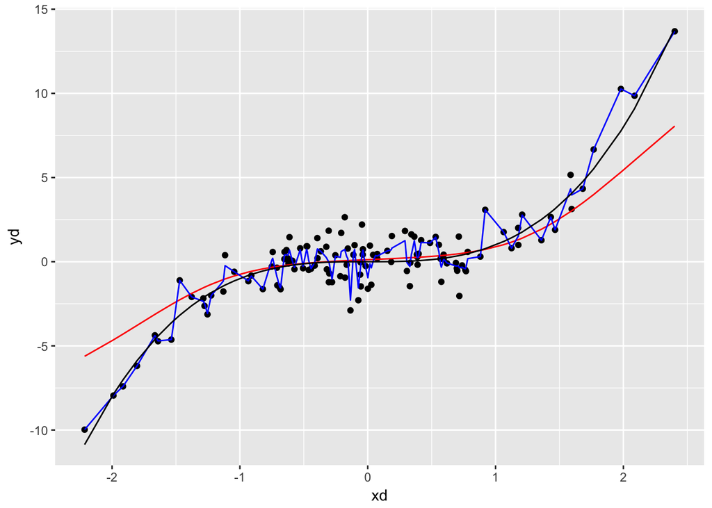

```r
training <- training %>% mutate(yd.ll.fit.lowflex = predict(object = ll.fit.lowflex))
training <- training %>% mutate(yd.ll.fit.highflex = predict(object = ll.fit.highflex))

ggplot(training) + geom_point(mapping = aes(x = xd, y = yd)) +
  geom_line(mapping = aes(x = xd, y = yd.ll.fit.lowflex), color = "red") + geom_line(mapping = aes(x = xd, y = yd.ll.fit.highflex), color = "blue")+  geom_line(mapping = aes(x = xd, y = xd^3))
```

We create a scatterplot with the command ggplot.

## Question 5

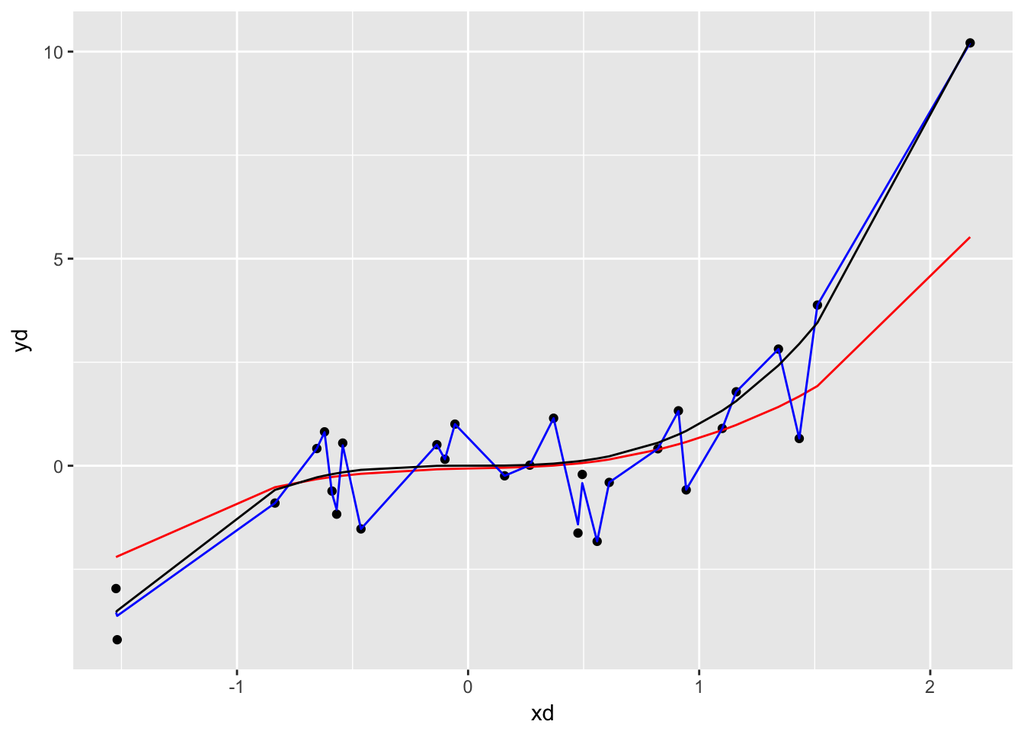

```r
ll.fit.lowflexT <- npreg(yd~xd^3 ,method = "ll",bws =  0.5,data=test)
ll.fit.highflexT <- npreg(yd~xd^3 ,method = "ll",bws =  0.01,data=test)

test<- test %>% mutate(yd.ll.fit.lowflexT = predict(object = ll.fit.lowflexT))
test <- test %>% mutate(yd.ll.fit.highflexT = predict(object = ll.fit.highflexT))

ggplot(test) + geom_point(mapping = aes(x = xd, y = yd)) +
  geom_line(mapping = aes(x = xd, y = yd.ll.fit.lowflexT), color = "red") + geom_line(mapping = aes(x = xd, y = yd.ll.fit.highflexT), color = "blue") + geom_line(mapping = aes(x = xd, y = xd^3))
```

The predictions of the highflex model are more variable. The predictions of the highflex have the least bias. But we can see that the bias is more important now.

## Question 6

```r
bandwidth <- seq(0.01, 0.5, by = .001)
```

We create the vector with the command seq.

## Question 7

```r
ll.fit.lowflexB <- lapply(X = bandwidth, FUN = function(bandwidth) {npreg(yd ~ xd^3, data = training, method = "ll", bws = bandwidth)})
```

We estimate the local linear model. We create a function which depends on the vector bandwidth.

## Question 8

```r
MSEtraining <- function(fit.model){
  predictions <- predict(object = fit.model, newdata = training)
  training %>% mutate(squared.error = (yd - predictions)^2) %>% summarize(mse = mean(squared.error))
}
MSEtraining.results <- unlist(lapply(X = ll.fit.lowflexB, FUN = MSEtraining))
```

We compute the MSE on the training data with the predict function.

## Question 9

```r
MSEtest <- function(fit.model){
  predictions <- predict(object = fit.model, newdata = test)
  test %>% mutate(squared.error = (yd - predictions)^2) %>% summarize(mse = mean(squared.error))
}
MSEtest.results <- unlist(lapply(X = ll.fit.lowflexB, FUN = MSEtest))
```

We compute the MSE on the test data with the predict function.

## Question 10

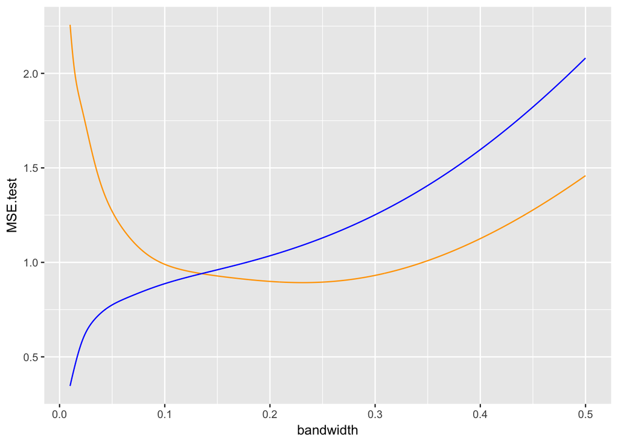

```r
MSE.table <- tbl_df(data.frame(bandwidth = bandwidth, MSE.train = MSEtraining.results, MSE.test = MSEtest.results))

attach(MSE.table)
ggplot(MSE.table) + geom_line(mapping=aes(x = bandwidth, y=MSE.test), color="orange") + geom_line(mapping=aes(x=bandwidth, y=MSE.train), color="blue")
```

# Task 3

## Question 1

In this question we use fred and read_excel to import the data because their size are important.

## Question 3

We merge the 2 data with the command merge